# **Regression Project: Boston House Price Prediction**

# **Marks: 60**

Welcome to the project on regression. We will use the **Boston house price dataset** for this project.

## **Objective**

The problem at hand is to **predict the housing prices of a town or a suburb based on the features of the locality provided to us**. In the process, we need to **identify the most important features affecting the price of the house**. We need to employ techniques of data preprocessing and build a linear regression model that predicts the prices for the unseen data.

## **Dataset**

Each record in the database describes a house in Boston suburb or town. The data was drawn from the Boston Standard Metropolitan Statistical Area (SMSA) in 1970. Detailed attribute information can be found below:

Attribute Information:

- **CRIM:** Per capita crime rate by town
- **ZN:** Proportion of residential land zoned for lots over 25,000 sq.ft.
- **INDUS:** Proportion of non-retail business acres per town
- **CHAS:** Charles River dummy variable (= 1 if tract bounds river; 0 otherwise)
- **NOX:** Nitric Oxide concentration (parts per 10 million)
- **RM:** The average number of rooms per dwelling
- **AGE:** Proportion of owner-occupied units built before 1940
- **DIS:** Weighted distances to five Boston employment centers
- **RAD:** Index of accessibility to radial highways
- **TAX:** Full-value property-tax rate per 10,000 dollars
- **PTRATIO:** Pupil-teacher ratio by town
- **LSTAT:** % lower status of the population
- **MEDV:** Median value of owner-occupied homes in 1000 dollars

## **Importing the necessary libraries and overview of the dataset**

```python
# Import libraries for data manipulation
import pandas as pd

import numpy as np

# Import libraries for data visualization
import matplotlib.pyplot as plt

import seaborn as sns

from statsmodels.graphics.gofplots import ProbPlot

# Import libraries for building linear regression model
from statsmodels.formula.api import ols

import statsmodels.api as sm

from sklearn.linear_model import LinearRegression

# Import library for preparing data
from sklearn.model_selection import train_test_split

# Import library for data preprocessing
from sklearn.preprocessing import MinMaxScaler

import warnings
warnings.filterwarnings("ignore")
```

### **Loading the data**

```python
df = pd.read_csv("Boston.csv")

df.head()
```

|  | CRIM | ZN | INDUS | CHAS | NOX | RM | AGE | DIS | RAD | TAX | PTRATIO | LSTAT | MEDV |
| --- | --- | --- | --- | --- | --- | --- | --- | --- | --- | --- | --- | --- | --- |
| 0 | 0.00632 | 18.0 | 2.31 | 0 | 0.538 | 6.575 | 65.2 | 4.0900 | 1 | 296 | 15.3 | 4.98 | 24.0 |
| 1 | 0.02731 | 0.0 | 7.07 | 0 | 0.469 | 6.421 | 78.9 | 4.9671 | 2 | 242 | 17.8 | 9.14 | 21.6 |
| 2 | 0.02729 | 0.0 | 7.07 | 0 | 0.469 | 7.185 | 61.1 | 4.9671 | 2 | 242 | 17.8 | 4.03 | 34.7 |
| 3 | 0.03237 | 0.0 | 2.18 | 0 | 0.458 | 6.998 | 45.8 | 6.0622 | 3 | 222 | 18.7 | 2.94 | 33.4 |
| 4 | 0.06905 | 0.0 | 2.18 | 0 | 0.458 | 7.147 | 54.2 | 6.0622 | 3 | 222 | 18.7 | 5.33 | 36.2 |

**Observation:**

- The price of the house indicated by the variable MEDV is the target variable and the rest of the variables are independent variables based on which we will predict the house price (MEDV).

### **Checking the info of the data**

```python
df.info()
```

```
<class 'pandas.core.frame.DataFrame'>
RangeIndex: 506 entries, 0 to 505
Data columns (total 13 columns):
 #   Column   Non-Null Count  Dtype
---  ------   --------------  -----
 0   CRIM     506 non-null    float64
 1   ZN       506 non-null    float64
 2   INDUS    506 non-null    float64
 3   CHAS     506 non-null    int64
 4   NOX      506 non-null    float64
 5   RM       506 non-null    float64
 6   AGE      506 non-null    float64
 7   DIS      506 non-null    float64
 8   RAD      506 non-null    int64
 9   TAX      506 non-null    int64
 10  PTRATIO  506 non-null    float64
 11  LSTAT    506 non-null    float64
 12  MEDV     506 non-null    float64
dtypes: float64(10), int64(3)
memory usage: 51.5 KB
```

**Observations:**

- There are a total of **506 non-null observations in each of the columns**. This indicates that there are **no missing values** in the data.
- There are **13 columns** in the dataset and **every column is of numeric data type**.

## **Exploratory Data Analysis and Data Preprocessing**

### **Summary Statistics of this Dataset**

### **Question 1:** Write the code to find the summary statistics and write your observations based on that. (4 Marks)

```python
df.describe()
```

|  | CRIM | ZN | INDUS | CHAS | NOX | RM | AGE | DIS | RAD | TAX | PTRATIO | LSTAT | MEDV |
| --- | --- | --- | --- | --- | --- | --- | --- | --- | --- | --- | --- | --- | --- |
| count | 506.000000 | 506.000000 | 506.000000 | 506.000000 | 506.000000 | 506.000000 | 506.000000 | 506.000000 | 506.000000 | 506.000000 | 506.000000 | 506.000000 | 506.000000 |
| mean | 3.613524 | 11.363636 | 11.136779 | 0.069170 | 0.554695 | 6.284634 | 68.574901 | 3.795043 | 9.549407 | 408.237154 | 18.455534 | 12.653063 | 22.532806 |
| std | 8.601545 | 23.322453 | 6.860353 | 0.253994 | 0.115878 | 0.702617 | 28.148861 | 2.105710 | 8.707259 | 168.537116 | 2.164946 | 7.141062 | 9.197104 |
| min | 0.006320 | 0.000000 | 0.460000 | 0.000000 | 0.385000 | 3.561000 | 2.900000 | 1.129600 | 1.000000 | 187.000000 | 12.600000 | 1.730000 | 5.000000 |
| 25% | 0.082045 | 0.000000 | 5.190000 | 0.000000 | 0.449000 | 5.885500 | 45.025000 | 2.100175 | 4.000000 | 279.000000 | 17.400000 | 6.950000 | 17.025000 |
| 50% | 0.256510 | 0.000000 | 9.690000 | 0.000000 | 0.538000 | 6.208500 | 77.500000 | 3.207450 | 5.000000 | 330.000000 | 19.050000 | 11.360000 | 21.200000 |
| 75% | 3.677083 | 12.500000 | 18.100000 | 0.000000 | 0.624000 | 6.623500 | 94.075000 | 5.188425 | 24.000000 | 666.000000 | 20.200000 | 16.955000 | 25.000000 |
| max | 88.976200 | 100.000000 | 27.740000 | 1.000000 | 0.871000 | 8.780000 | 100.000000 | 12.126500 | 24.000000 | 711.000000 | 22.000000 | 37.970000 | 50.000000 |

**Observations:*__***

I will take this opportunity to investigate the exact meaning of each feature. Then, based on what the statistics show, I will draw inferences and provide observations.

1. CRIM: Per capita crime rate by town. Definition of feature: CRIM is a measure of crime rate per capita by town. It is calculated by dividing the total number of crimes by the total population of a town. Higher values indicate higher crime rates, while lower values indicate lower crime rates.

1. ZN: Proportion of residential land zoned for lots over 25,000 sq.ft. Definition of feature: This means that the proportion of land zoned for residential use that allows for lots that are larger than 25,000 square feet.

1. INDUS: Proportion of non-retail business acres per town Definition of feature: Proportion of non-retail business acres per town is a measure of the amount of land used for non-retail businesses such as factories, offices, warehouses, etc. per town. This measure gives an indication of the industrial activity in each town.

1. CHAS: Charles River dummy variable (= 1 if tract bounds river; 0 otherwise) Definition of feature: CHAS is a dummy variable created to represent whether or not a census tract bounds the Charles River in the Boston area. It is a binary variable, meaning it has two possible values: 1 if the tract borders the river, and 0 otherwise. Observations: The probability distribution for CHAS is a Bernoulli distribution, which is a special case of the binomial distribution. The probability of success (a tract bouding the river) is 0.06917 and the probability of failure (no tract bouding the river) is 1-06917=0.93083.
1. NOX: Nitric Oxide concentration (parts per 10 million) Definition of feature: NOX is a term used to refer to the concentration of Nitric Oxide in the atmosphere. Nitric Oxide is an air pollutant that is created by burning fossil fuels such as gasoline, diesel, and natural gas. NOX is typically measured in parts per 10 million (ppm). High levels of NOX can lead to increased levels of ground-level ozone and smog, which can be harmful to human health.

1. RM: The average number of rooms per dwelling Definition of feature: RM refers to the average number of rooms per dwelling is a measure of the size of a dwelling and is typically used to measure a household's wealth. It is an indicator of the amount of space available for a household and is calculated by dividing the total number of rooms in a dwelling by the number of households that occupy the dwelling.

--> QUESTION 1 OBSERVATIONS: The probability distribution for RM looks like a normal distribution. The mean of 6.284634 suggests that most of the observations have a value of 6. The std of 0.702617 shows that the values are relatively close to the mean, with the majority of the values falling somewhere between 5.58 and 6.9 (+/- 1 std from the mean). The min of 3.561 shows that there is a small probability of an observation having a value of 3 rooms, while the max of 8.78 shows that there is an even smaller probability of an observation having a value of 8 rooms or more.

1. AGE: Proportion of owner-occupied units built before 1940 Definition of feature: AGE: Proportion of owner-occupied units built before 1940 is a statistic that indicates the percentage of homes owned by people that were built before 1940. This could provide insight into the average age of the housing stock in an area and the number of people living in older homes.

--> QUESTION 1 OBSERVATIONS: Because the mean is lower than the median, this indicates that there are more values above the mean than below it. This would create a left skewed distribution with more data points extending out to the right and a long tail of data points extending out to the left. This could be due to the fact that most of the homes owned by people were built before 1940, which would result in a larger proportion of older homes and a smaller proportion of newer homes.

1. DIS: Weighted distances to five Boston employment centers Definiton of feature: DIS refers to weighted distances to five Boston employment centers and refers to data set that contains information about the weighted distances from a series of locations to five major employment centers in Boston. This data set can be used to measure the proximity of a given location to the employment centers, which can be used to inform decisions such as selecting real estate, determining the availability of job opportunities, and more.

--> QUESTION 1 OBSERVATIONS: The probability distribution for DIS would be a normal distribution centered around the mean of 3.795043, with a standard deviation of 2.10571. The distribution would be skewed to the right, with the majority of the data points falling within the range of 1.1296 to 12.1265. The 25th percentile would be around 2.100175, the 50th percentile at 3.20745, and the 75th percentile at 5.188425.

1. RAD: Index of accessibility to radial highways

Description of feature: RAD stands for the “Radial Accessibility Distance” index, which is used to measure the accessibility to radial highways from a given location. It is calculated by measuring the distance between a given location and the nearest radial highway, taking into account the number of intersections that must be crossed. A radial highway is a road or highway that radiates outward from a central point. These roads often lead to other cities or towns and can be used to quickly access destinations farther away. Radial highways are often used to connect major cities and form the backbone of many transportation networks. Generally, RAD scores can range from 1-24. Scores of 1-4 indicate good accessibility, scores of 5-12 indicate moderate accessibility, and scores of 13-24 indicate poor accessibility.

1. TAX: Full-value property-tax rate per 10,000 dollars

Description of feature: TAX refers to full-value property-tax rate per 10,000 dollars is a term used to describe the rate of property tax that is applied to the assessed value of a property. This rate is usually expressed as a percentage and is calculated by dividing the total property tax due by the assessed value of the property, then multiplying by 10,000.

--> QUESTION 1 OBSERVATIONS: TAX follows a right-skewed distribution. The fact that the median (50%) is less than the mean (408.237154) and also less than the third quartile (75% = 666) confirms this. The min value is 187 and max value is 711 which shows that there is a big range of values for TAX. In this distribution, the standard deviation (168.537116) also indicates that the data is quite spread out, with values deviating significantly from the mean.

1. PTRATIO: Pupil-teacher ratio by town

Description of feature: "Pupil-teacher ratio by town" (PTRATIO) is a measure of the number of students per teacher in a given town. It is calculated by dividing the total number of students in a town by the total number of teachers in that town.This ratio is commonly used as an indicator of the level of resources available to students in a given area, with a lower ratio indicating a higher level of resources (more teachers per student). This measure is also used to evaluate the quality of education provided by a school district, as a lower ratio often suggests a higher level of individual attention for each student.

1. LSTAT: % lower status of the population

Description of feature: LSTAT is a statistic which measures the percentage of the population in a certain area that are in the lower socioeconomic bracket. This statistic is usually used to measure poverty levels and socio-economic disparities within a particular area.

1. MEDV: Median value of owner-occupied homes in 1000 dollars

Feature description: "Median value of owner-occupied homes in $1000" (MEDV) is a measure of the median value of homes that are occupied by their owners. The median value is the middle value of a dataset when it is arranged in ascending or descending order. It is a commonly used measure of central tendency that is less sensitive to outliers than the mean. A higher value of MEDV indicates a higher median value of homes in a given area, while a lower value of MEDV indicates a lower median value of homes in a given area. This measure is commonly used in fields such as real estate, economics, and urban planning to understand and compare the housing market conditions of different areas.

--> QUESTION 1 OBSERVATIONS: Based on the statistics provided, it appears that the probability distribution of your data is likely a right-skewed distribution. The mean of 22.53 is greater than the median of 21.2, which suggests that the distribution is skewed to the right. The standard deviation of 9.187 is relatively large in comparison to the mean, which also supports a right-skewed distribution. The minimum value of 5 and maximum value of 50 are relatively far from the quartiles, which also supports a right-skewed distribution. The difference between the 75th and 50th percentiles is 3.8, and the difference between the 50th and 25th percentiles is 4.175, which is consistent with a right-skewed distribution where the 75th percentile should be greater than the median, and the median should be greater than the 25th percentile.

### **Univariate Analysis**

**Let's check the distribution of the variables**

### **Question 2:** Write your observations based on the below univariate plots. (4 Marks)

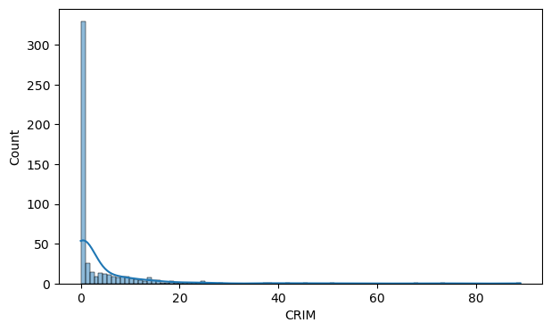

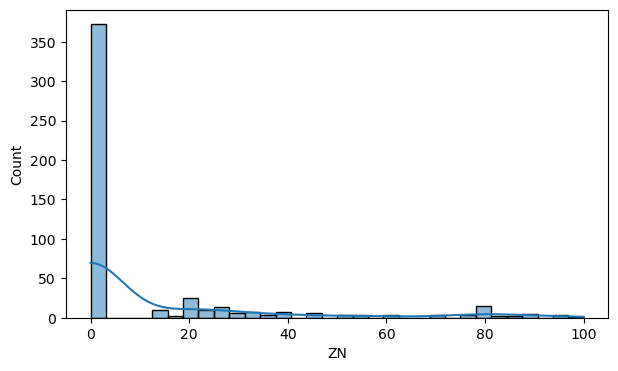

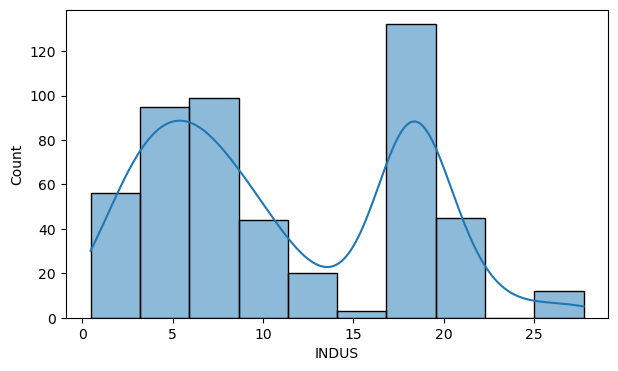

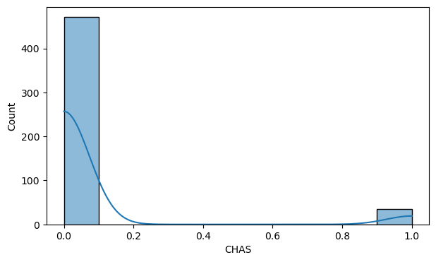

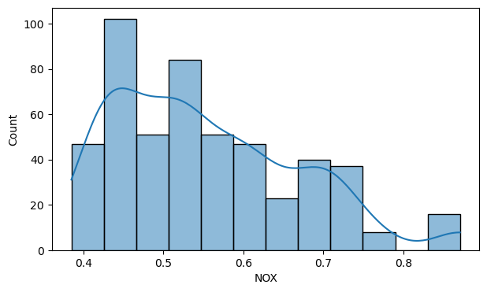

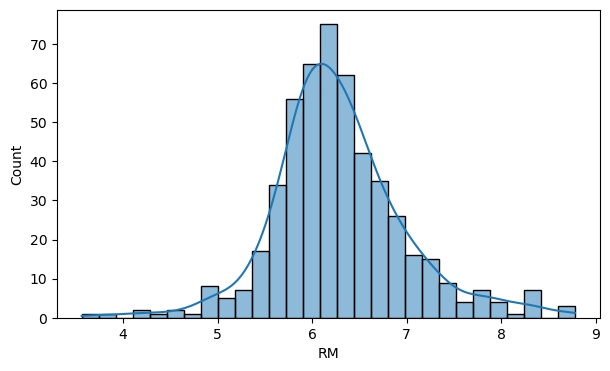

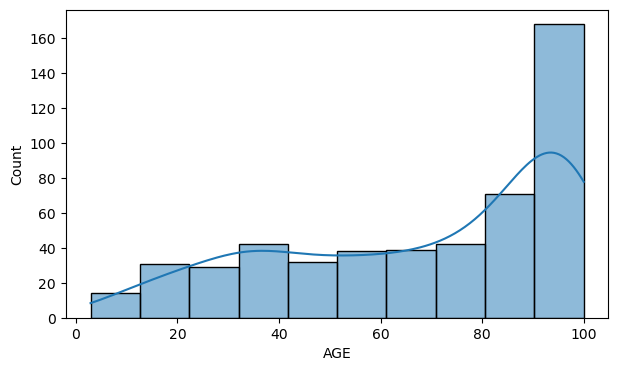

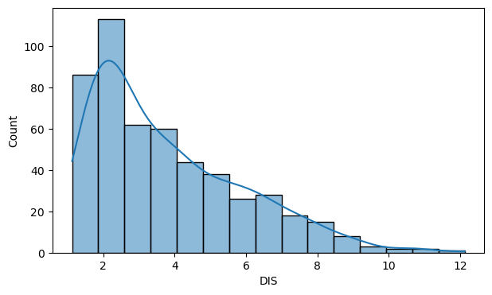

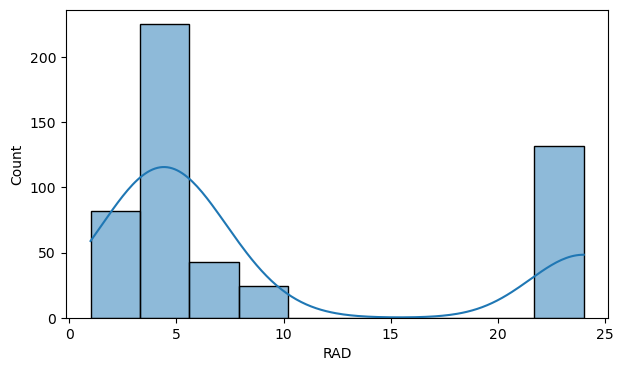

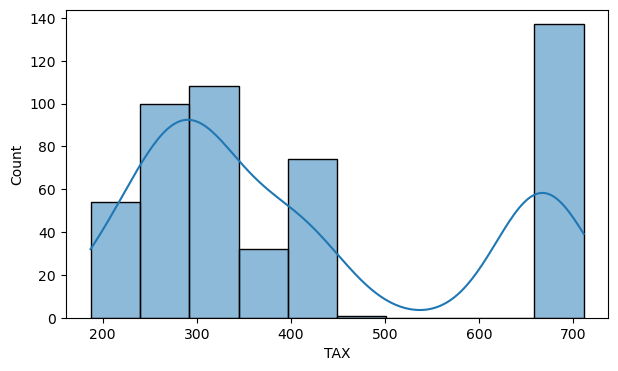

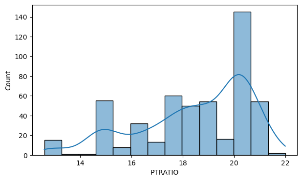

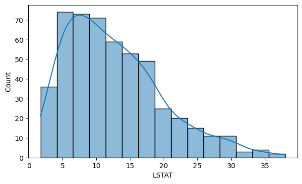

[1 more figures not shown]

```python
# Plotting all the columns to look at their distributions
for i in df.columns:

    plt.figure(figsize = (7, 4))

    sns.histplot(data = df, x = i, kde = True)

    plt.show()
```

**Observations:**__****

We can use our observations in Question 1, which were based pure statistics (without seeing the spread) to validate the univariate analysis.

As the dependent variable is sightly skewed, we will apply a **log transformation on the 'MEDV' column** and check the distribution of the transformed column.

```python
df['MEDV_log'] = np.log(df['MEDV'])
```

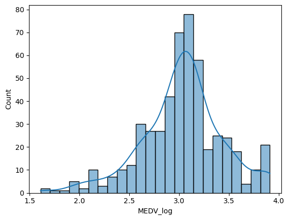

```python
sns.histplot(data = df, x = 'MEDV_log', kde = True)
```

**Observation:**

- The log-transformed variable (**MEDV_log**) appears to have a **nearly normal distribution without skew**, and hence we can proceed.

Before creating the linear regression model, it is important to check the bivariate relationship between the variables. Let's check the same using the heatmap and scatterplot.

### **Bivariate Analysis**

**Let's check the correlation using the heatmap**

### **Question 3:** Write the code to plot the correlation heatmap and write your observations based on that. (6 Marks)

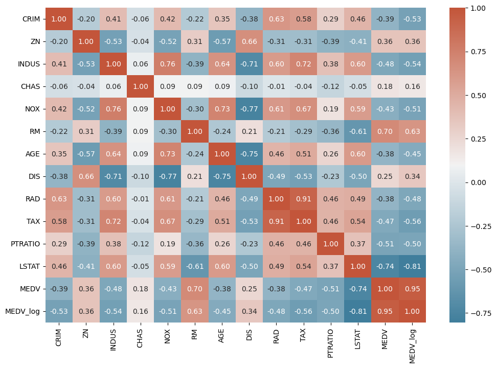

```python
plt.figure(figsize = (12, 8))

cmap = sns.diverging_palette(230, 20, as_cmap = True)

corr=df.corr()

sns.heatmap(corr, annot = True, fmt = '.2f', cmap = cmap)

plt.show()
```

**Observations:**__****

1. Low or no correlation (values close to 0)

CHAS is not correlated to NOX, RM, AGE or INDUS.

1. Positive correlation (as one variable increases, so does the other) - Red

High (>.9): TAX is highly positively correlated with RAD as well as MEDV to MEDV_log Moderate-high (between .7 and .9): TAX is moderate-highly correlated to INDUS, MEDV is moderately correlated to RM, NOX is moderate-highly correlated to INDUS, AGE is moderate-highly correlated with NOX.

1. Negative correlation (as one variable increases, the other variable descreases) - Blue

Now, we will visualize the relationship between the pairs of features having significant correlations.

### **Visualizing the relationship between the features having significant correlations (>= 0.7 or <= -0.7)**

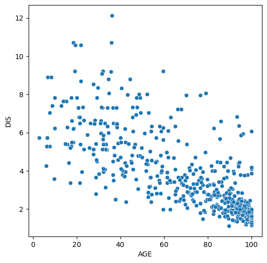

```python
# Scatterplot to visualize the relationship between AGE and DIS
plt.figure(figsize = (6, 6))

sns.scatterplot(x = 'AGE', y = 'DIS', data = df)

plt.show()
```

**Observations:**

- The distance of the houses to the Boston employment centers appears to decrease moderately as the the proportion of the old houses increase in the town. It is possible that the Boston employment centers are located in the established towns where proportion of owner-occupied units built prior to 1940 is comparatively high.

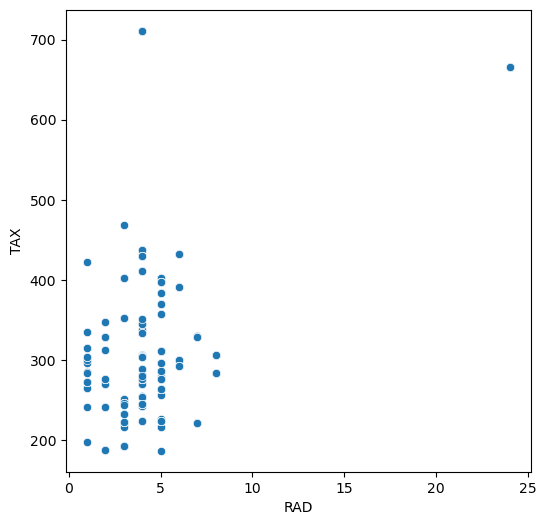

```python
# Scatterplot to visulaize the relationship between RAD and TAX
plt.figure(figsize = (6, 6))

sns.scatterplot(x = 'RAD', y = 'TAX', data = df)

plt.show()
```

**Observations:**

- The correlation between RAD and TAX is very high. But, no trend is visible between the two variables.
- The strong correlation might be due to outliers.

Let's check the correlation after removing the outliers.

```python
# Remove the data corresponding to high tax rate
df1 = df[df['TAX'] < 600]

# Import the required function
from scipy.stats import pearsonr

# Calculate the correlation
print('The correlation between TAX and RAD is', pearsonr(df1['TAX'], df1['RAD'])[0])
```

```
The correlation between TAX and RAD is 0.24975731331429196
```

**Observation:**

- So, the high correlation between TAX and RAD is due to the outliers. The tax rate for some properties might be higher due to some other reason.

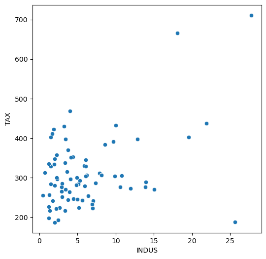

```python
# Scatterplot to visualize the relationship between INDUS and TAX
plt.figure(figsize = (6, 6))

sns.scatterplot(x = 'INDUS', y = 'TAX', data = df)

plt.show()
```

**Observations:**

- The tax rate appears to increase with an increase in the proportion of non-retail business acres per town. This might be due to the reason that the variables TAX and INDUS are related with a third variable.

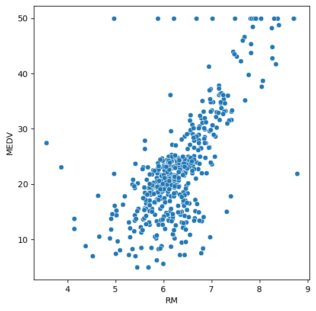

```python
# Scatterplot to visulaize the relationship between RM and MEDV
plt.figure(figsize = (6, 6))

sns.scatterplot(x = 'RM', y = 'MEDV', data = df)

plt.show()
```

**Observations:**

- The price of the house seems to increase as the value of RM increases. This is expected as the price is generally higher for more rooms.
- There are a few outliers in a horizontal line as the MEDV value seems to be capped at 50.

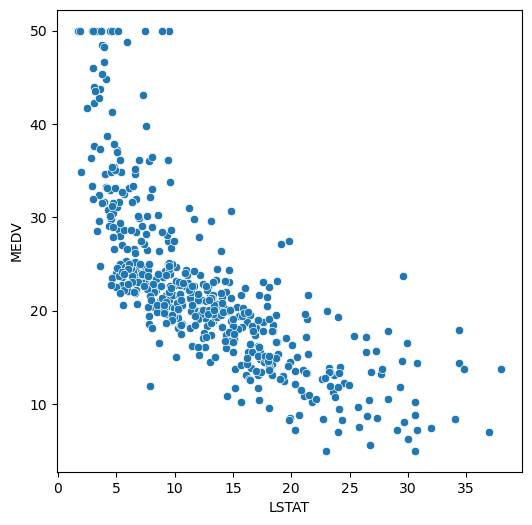

```python
# Scatterplot to visulaize the relationship between LSTAT and MEDV
plt.figure(figsize = (6, 6))

sns.scatterplot(x = 'LSTAT', y = 'MEDV', data = df)

plt.show()
```

**Observations:**

- The price of the house tends to decrease with an increase in LSTAT. This is also possible as the house price is lower in areas where lower status people live.
- There are few outliers and the data seems to be capped at 50.

### **Question 4** (8 Marks):

- **Create a scatter plot to visualize the relationship between the remaining features having significant correlations (>= 0.7 or <= -0.7) (4 Marks)**
  - INDUS and NOX
  - AGE and NOX
  - DIS and NOX
- **Write your observations from the plots (4 Marks)**

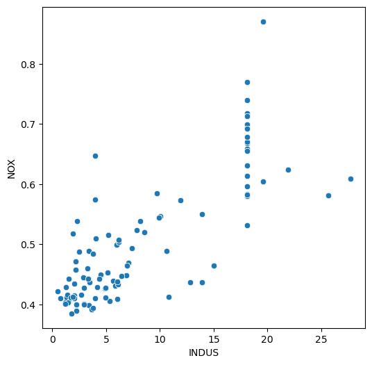

```python
# Scatterplot to visualize the relationship between INDUS and NOX
plt.figure(figsize = (6, 6))

sns.scatterplot(x = 'INDUS', y = 'NOX', data = df)

plt.show()
```

**Observations:*__***

Nitric Oxide levels appear to increase as the number of factories increase. This makes sense as industries emit pollution. There is an interesting linear spike in towns at the 18 mark, indicating that these towns with INDUS values of 18 will experiece higher levels of Nitrix Oxide than others.

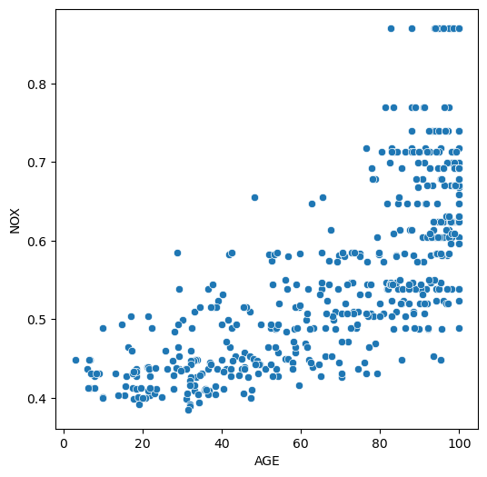

```python
# Scatterplot to visualize the relationship between AGE and NOX
plt.figure(figsize = (6, 6))

sns.scatterplot(x = 'AGE', y = 'NOX', data = df)

plt.show()
```

**Observations:*__*** This scatterplot shows that areas with older homes tend to have higher levels of nitric oxide in the air. There is an increasing trend with higher concentration of homes betwee 80-100 (AGE). Younger homes have relatively stable (lower) levels between .4-.6 (NOX).

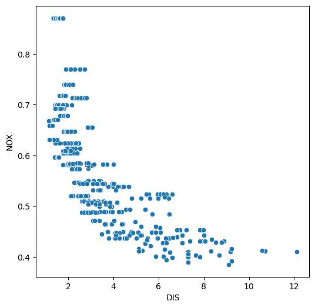

```python
# Scatterplot to visualize the relationship between DIS and NOX
plt.figure(figsize = (6, 6))

sns.scatterplot(x = 'DIS', y = 'NOX', data = df)

plt.show()
```

We have seen that the variables LSTAT and RM have a linear relationship with the dependent variable MEDV. Also, there are significant relationships among few independent variables, which is not desirable for a linear regression model. Let's first split the dataset.

### **Split the dataset**

Let's split the data into the dependent and independent variables and further split it into train and test set in a ratio of 70:30 for train and test sets.

```python
# Separate the dependent variable and indepedent variables
Y = df['MEDV_log']

X = df.drop(columns = {'MEDV', 'MEDV_log'})

# Add the intercept term
X = sm.add_constant(X)
```

```python
# splitting the data in 70:30 ratio of train to test data
X_train, X_test, y_train, y_test = train_test_split(X, Y, test_size = 0.30, random_state = 1)
```

Next, we will check the multicollinearity in the training dataset.

### **Check for Multicollinearity**

We will use the Variance Inflation Factor (VIF), to check if there is multicollinearity in the data.

Features having a VIF score > 5 will be dropped / treated till all the features have a VIF score < 5

```python
from statsmodels.stats.outliers_influence import variance_inflation_factor

# Function to check VIF
def checking_vif(train):
    vif = pd.DataFrame()
    vif["feature"] = train.columns

    # Calculating VIF for each feature
    vif["VIF"] = [
        variance_inflation_factor(train.values, i) for i in range(len(train.columns))
    ]
    return vif


print(checking_vif(X_train))
```

```
    feature         VIF
0     const  535.372593
1      CRIM    1.924114
2        ZN    2.743574
3     INDUS    3.999538
4      CHAS    1.076564
5       NOX    4.396157
6        RM    1.860950
7       AGE    3.150170
8       DIS    4.355469
9       RAD    8.345247
10      TAX   10.191941
11  PTRATIO    1.943409
12    LSTAT    2.861881
```

**Observations:**

- There are two variables with a high VIF - RAD and TAX (greater than 5).
- Let's remove TAX as it has the highest VIF values and check the multicollinearity again.

### **Question 5:** Drop the column 'TAX' from the training data and check if multicollinearity is removed? (2 Marks)

```python
# Create the model after dropping TAX
X_train = X_train.drop(columns=["TAX"], axis=1) # drop from training data
X_test = X_test.drop(columns=["TAX"], axis=1) # drop from test data

# Check for VIF
print(checking_vif(X_train))
```

```
    feature         VIF
0     const  532.025529
1      CRIM    1.923159
2        ZN    2.483399
3     INDUS    3.270983
4      CHAS    1.050708
5       NOX    4.361847
6        RM    1.857918
7       AGE    3.149005
8       DIS    4.333734
9       RAD    2.942862
10  PTRATIO    1.909750
11    LSTAT    2.860251
```

Now, we will create the linear regression model as the VIF is less than 5 for all the independent variables, and we can assume that multicollinearity has been removed between the variables.

### **Question 6:** Write the code to create the linear regression model and print the model summary. Write your observations from the model. (6 Marks)

**Hint:** Use the sm.OLS() model on the training data

```python
# Create the model

import statsmodels.api as sm
from sklearn.metrics import r2_score, mean_absolute_percentage_error, mean_absolute_error, mean_squared_error

# Model Performance on test and train data
def model_pref(olsmodel, x_train, x_test):

    # Insample Prediction
    y_pred_train = olsmodel.predict(x_train)
    y_observed_train = y_train

    # Prediction on test data
    y_pred_test = olsmodel.predict(x_test)
    y_observed_test = y_test

    print(
        pd.DataFrame(
            {
                "Data": ["Train", "Test"],
                "RMSE": [
                    np.sqrt(mean_squared_error(y_pred_train, y_observed_train)),
                    np.sqrt(mean_squared_error(y_pred_test, y_observed_test)),
                ],
                "MAE": [
                    mean_absolute_error(y_pred_train, y_observed_train),
                    mean_absolute_error(y_pred_test, y_observed_test),
                ],

                "r2": [
                    r2_score(y_pred_train, y_observed_train),
                    r2_score(y_pred_test, y_observed_test),
                ],
            }
        )
    )

model1 = sm.OLS(y_train, X_train).fit()

# Get the model summary
model1.summary()

print(model1.summary())

# Checking model performance
model_pref(model1, X_train, X_test)
```

```
                            OLS Regression Results
==============================================================================
Dep. Variable:               MEDV_log   R-squared:                       0.769
Model:                            OLS   Adj. R-squared:                  0.761
Method:                 Least Squares   F-statistic:                     103.3
Date:                Sat, 21 Jan 2023   Prob (F-statistic):          1.40e-101
Time:                        21:06:32   Log-Likelihood:                 76.596
No. Observations:                 354   AIC:                            -129.2
Df Residuals:                     342   BIC:                            -82.76
Df Model:                          11
Covariance Type:            nonrobust
==============================================================================
                 coef    std err          t      P>|t|      [0.025      0.975]
------------------------------------------------------------------------------
const          4.6324      0.243     19.057      0.000       4.154       5.111
CRIM          -0.0128      0.002     -7.445      0.000      -0.016      -0.009
ZN             0.0010      0.001      1.425      0.155      -0.000       0.002
INDUS         -0.0004      0.003     -0.148      0.883      -0.006       0.005
CHAS           0.1196      0.039      3.082      0.002       0.043       0.196
NOX           -1.0598      0.187     -5.675      0.000      -1.427      -0.692
RM             0.0532      0.021      2.560      0.011       0.012       0.094
AGE            0.0003      0.001      0.461      0.645      -0.001       0.002
DIS           -0.0503      0.010     -4.894      0.000      -0.071      -0.030
RAD            0.0076      0.002      3.699      0.000       0.004       0.012
PTRATIO       -0.0452      0.007     -6.659      0.000      -0.059      -0.032
LSTAT         -0.0298      0.002    -12.134      0.000      -0.035      -0.025
==============================================================================
Omnibus:                       30.699   Durbin-Watson:                   1.923
Prob(Omnibus):                  0.000   Jarque-Bera (JB):               83.718
Skew:                           0.372   Prob(JB):                     6.62e-19
Kurtosis:                       5.263   Cond. No.                     2.09e+03
==============================================================================

Notes:
[1] Standard Errors assume that the covariance matrix of the errors is correctly specified.
[2] The condition number is large, 2.09e+03. This might indicate that there are
strong multicollinearity or other numerical problems.
    Data      RMSE       MAE        r2
0  Train  0.194892  0.142894  0.698983
1   Test  0.198258  0.149346  0.649850
```

**Observations:**_****

Based on these values provided, it appears that the model is performing well on the training set, but not as well on the test set. The training set has lower RMSE, MAE, and higher r2 values compared to the test set, which suggests that the model is overfitting to the training data.

RMSE and MAE are both measures of model accuracy, with lower values indicating better accuracy. The difference in RMSE and MAE between training and test set is not very large, which suggest that the model is not performing extremely poorly on the test set.

r2 is a measure of how well the model fits the data, with a value of 1 indicating a perfect fit. The r2 value on the training set is higher than on the test set, which again suggests overfitting.

In general, the model should be fine-tuned to improve its performance on unseen data. You can try reducing model complexity, adding regularization, or adding more data to the training set. You can also try different algorithms and see which one performs better on the test set.

Looking at the p-value>.05, we see that ZN, INDUS, AGE should be dropped and the algorithm should be run again.